# Session2: Introduction to Data Frame

Sumeet Pal Singh  
06 April, 2020

Notes by: Yura Song

### Course Organization

- YouTube Live Stream accessible for later
- Github site for course: https://github.com/sumeetpalsingh/R_course/

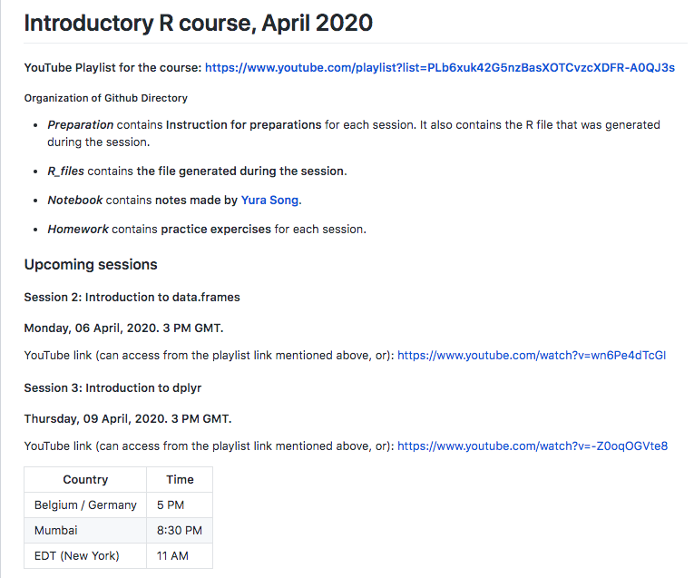

### Course Timeline

1. Introduction to RStudio
2. 2-D data structures
3. Tidyverse
4. Read / write files
5. Introduction to ggplot2
6. ggplot2 Exercises
7. Introduction to R Markdown and Shiny App

### Iris Dataset

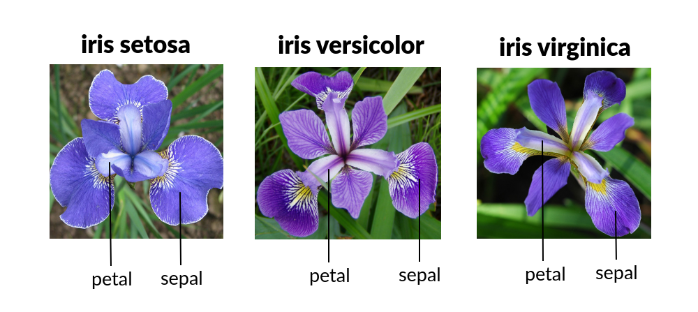

Generated by a biologist Ronald Fisher in 1936.

### Iris Data

The data set consists of 50 samples from each of three species of Iris:

- Iris setosa
- Iris virginica
- Iris versicolor

Four **features** were measured from each sample:

the length and the width of the sepals and petals, in centimeters.

### Iris data.frame (Tidy / Long)

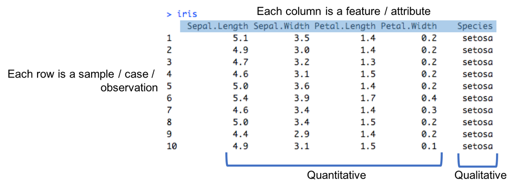

### Explore a dataframe: See summary

```r
summary(iris)
```

```
  Sepal.Length    Sepal.Width     Petal.Length    Petal.Width
 Min.   :4.300   Min.   :2.000   Min.   :1.000   Min.   :0.100
 1st Qu.:5.100   1st Qu.:2.800   1st Qu.:1.600   1st Qu.:0.300
 Median :5.800   Median :3.000   Median :4.350   Median :1.300
 Mean   :5.843   Mean   :3.057   Mean   :3.758   Mean   :1.199
 3rd Qu.:6.400   3rd Qu.:3.300   3rd Qu.:5.100   3rd Qu.:1.800
 Max.   :7.900   Max.   :4.400   Max.   :6.900   Max.   :2.500
       Species
 setosa    :50
 versicolor:50
 virginica :50
```

### Explore a dataframe: Plot the features

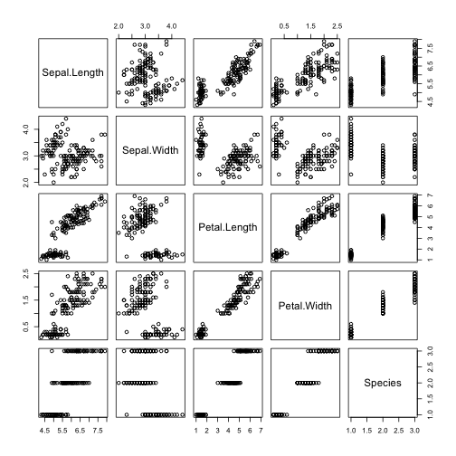

```r
plot(iris)
```